# CSE 4334 Team 6 Project

Azmi Alinufael, Maheer Jawwad, Sujana Kabir

2025-11-07

# 1. Introduction & Data Preparation

## 1.1 Project Overview

This project analyzes the relationship between demographic and individual medical costs. Using the “Insurance Claim Prediction” dataset from Kaggle, we aim to:

1. Identify key factors influencing insurance charges.
2. Build and compare regression models to predict claim costs, per our proposal.
3. Evaluate model accuracy using R-squared and Root Mean Squared Error (RMSE), as requested.
4. Explore customer segments using K-Means clustering.

## 1.2 Preparing Data

```r
# Load necessary libraries

library(ggplot2)
library(caret)
library(dplyr)
library(corrplot)
library(GGally)
library(randomForest)
library(pROC)
#Loading and Reading Dataset

insure <- read.csv("Insurance.csv")

# Exploring the structure of the dataset
summary(insure)
```

```
##       age             sex              bmi           children
##  Min.   :18.00   Min.   :0.0000   Min.   :15.96   Min.   :0.000
##  1st Qu.:27.00   1st Qu.:0.0000   1st Qu.:26.30   1st Qu.:0.000
##  Median :39.00   Median :1.0000   Median :30.40   Median :1.000
##  Mean   :39.21   Mean   :0.5052   Mean   :30.66   Mean   :1.095
##  3rd Qu.:51.00   3rd Qu.:1.0000   3rd Qu.:34.69   3rd Qu.:2.000
##  Max.   :64.00   Max.   :1.0000   Max.   :53.13   Max.   :5.000
##      smoker           region         charges      insuranceclaim
##  Min.   :0.0000   Min.   :0.000   Min.   : 1122   Min.   :0.0000
##  1st Qu.:0.0000   1st Qu.:1.000   1st Qu.: 4740   1st Qu.:0.0000
##  Median :0.0000   Median :2.000   Median : 9382   Median :1.0000
##  Mean   :0.2048   Mean   :1.516   Mean   :13270   Mean   :0.5852
##  3rd Qu.:0.0000   3rd Qu.:2.000   3rd Qu.:16640   3rd Qu.:1.0000
##  Max.   :1.0000   Max.   :3.000   Max.   :63770   Max.   :1.0000
```

```r
# Checking for missing values
# looks clean, no missing values so far
sum(is.na(insure))
```

```
## [1] 0
```

# 2. Exploratory Data Analysis (EDA)

## 2.1 Data Preprocessing

```r
# Converting categorical variables to factors
insure$sex <- as.factor(insure$sex)
insure$smoker <- as.factor(insure$smoker)
insure$region <- as.factor(insure$region)

#verifying the types
str(insure[,c("sex","smoker","region")])
```

```
## 'data.frame':    1338 obs. of  3 variables:
##  $ sex   : Factor w/ 2 levels "0","1": 1 2 2 2 2 1 1 1 2 1 ...
##  $ smoker: Factor w/ 2 levels "0","1": 2 1 1 1 1 1 1 1 1 1 ...
##  $ region: Factor w/ 4 levels "0","1","2","3": 4 3 3 2 2 3 3 2 1 2 ...
```

## 2.2 Target Variable: Charges

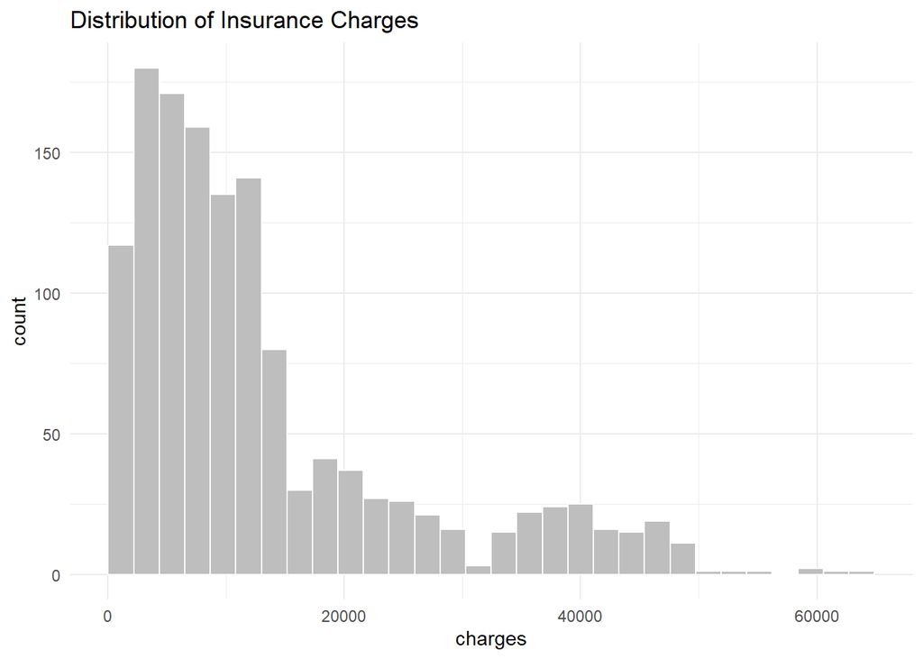

```r
# Checking the distribution of our target variable, charges
ggplot(insure, aes(x = charges)) +
  geom_histogram(bins = 30, fill = "grey", color = "white") +
  labs(title = "Distribution of Insurance Charges") +
  theme_minimal()
```

## 2.3 Correlation Analysis

A correlation matrix of numeric variables highlights initial relationships. age (0.30) and bmi (0.20) show moderate positive correlations with charges. The strongest relationships, however, will likely be from categorical variables (like smoker).

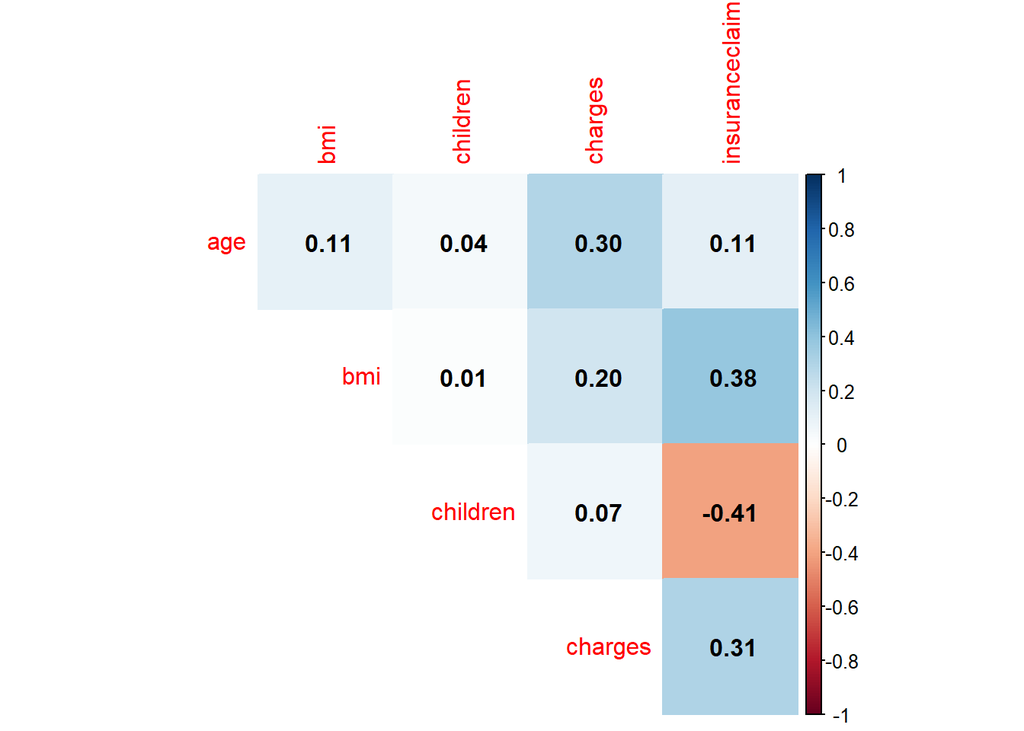

```r
# selecting only numeric columns first
numeric_insure <- insure %>% select_if(is.numeric)
cor_matrix <- cor(numeric_insure)

# Plotting the heatmap
corrplot(cor_matrix, method = "color", addCoef.col = "black", type="upper", diag=FALSE)
```

## 2.4. Key Relationships (Bivariate)

Visual analysis confirms the smoker variable is the most significant differentiator for charges. For smokers, charges increase substantially with both age and bmi. Non-smokers also see an increase with age, but at a much lower rate.

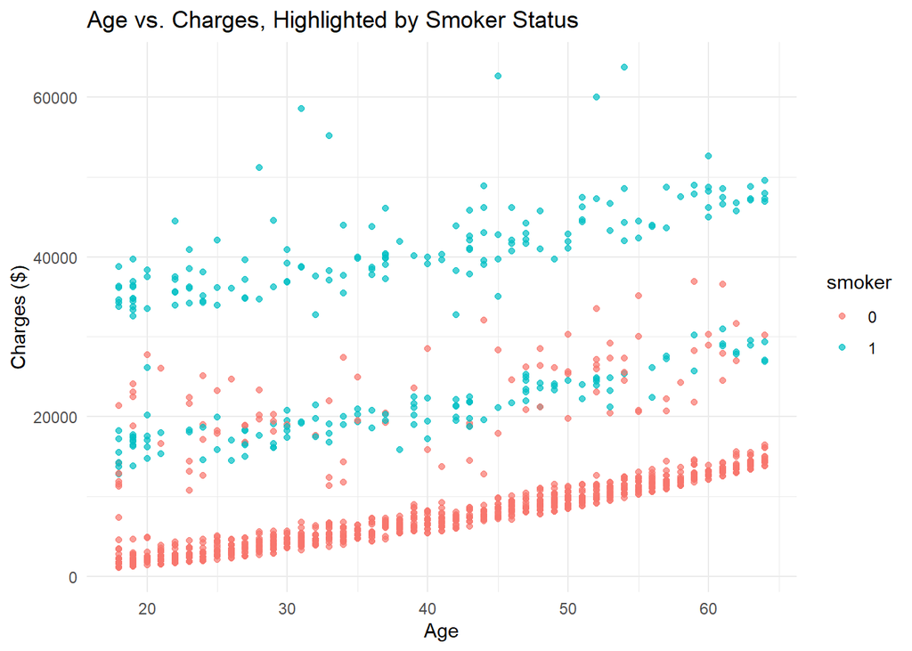

```r
# Scatter: Age vs Charges, colored by Smoker
ggplot(insure, aes(x = age, y = charges, color = smoker)) +
  geom_point(alpha=0.7) +
  labs(title = "Age vs. Charges, Highlighted by Smoker Status",
       x = "Age", y = "Charges ($)") +
  theme_minimal()
```

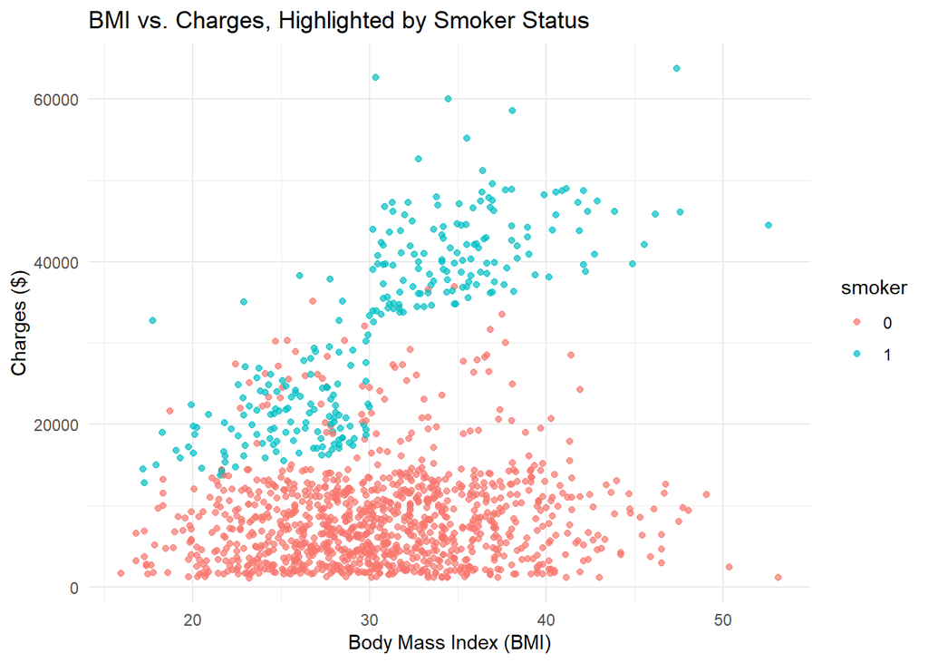

```r
# Scatter: BMI vs Charges, colored by Smoker
ggplot(insure, aes(x = bmi, y = charges, color = smoker)) +
  geom_point(alpha=0.7) +
  labs(title = "BMI vs. Charges, Highlighted by Smoker Status",
       x = "Body Mass Index (BMI)", y = "Charges ($)") +
  theme_minimal()
```

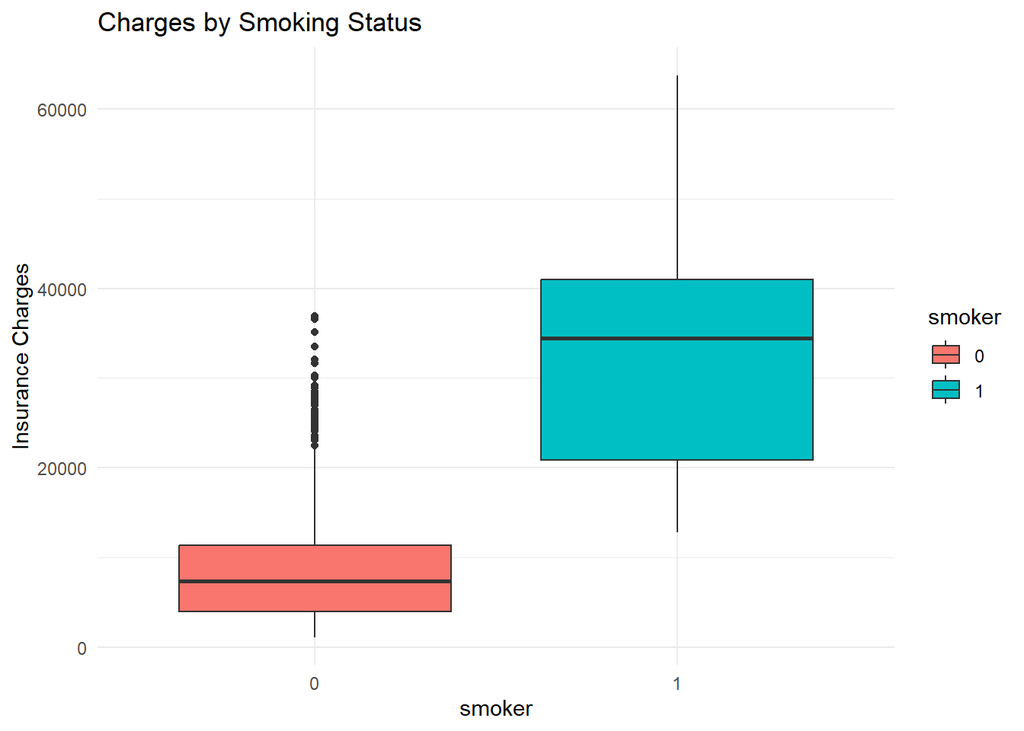

```r
# Boxplot of Charges by Smoker Status
ggplot(insure, aes(x = smoker, y = charges, fill = smoker)) +
  geom_boxplot() +
  labs(title = "Charges by Smoking Status", y = "Insurance Charges") +
  theme_minimal()
```

## 2.5 EDA Summary

The dataset includes 1338 observations and 8 variables: age, sex, bmi, children, smoker, region, charges, and insuranceclaim. No missing values were found. Categorical variables (sex, smoker, and region) were converted into factors for analysis. Our target variable (charges) is heavily skewed to the right, with a small number of high cost outliers corresponding to expensive medical claims. The descriptive stats and visuals show that smokers consistently incur higher medical charges compared to non-smokers, and that both age and BMI have moderate positive relationships with charges. The variable insuranceclaim serves as a potential target for later classification tasks but is excluded for out regression modeling of charges to avoid leakage. Overall, smoking, status, BMI, and age are expected to be the most significant predictors of individual medical costs.

# 3. K-Means Clustering

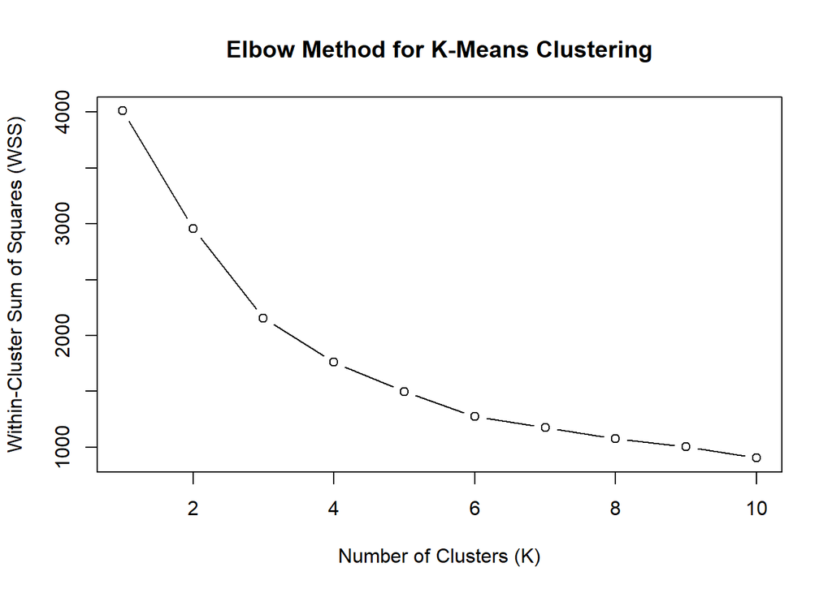

```r
# data prep for clustering
cluster_data <- insure %>%
  select(age, bmi, children)
scaled_cluster_data <- scale(cluster_data)

# Determining optimal number of clusters (K) using the Elbow Method
wss <- numeric(10)
for (i in 1:10) {
  wss[i] <- sum(kmeans(scaled_cluster_data, centers = i)$withinss)
}
plot(1:10, wss, type = "b", xlab = "Number of Clusters (K)",
     ylab = "Within-Cluster Sum of Squares (WSS)",
     main = "Elbow Method for K-Means Clustering")
```

Running K-means clustering:

```r
# Run K-Means
set.seed(42)
kmeans_model <- kmeans(scaled_cluster_data, centers = 4, nstart = 25)
insure$cluster <- as.factor(kmeans_model$cluster)

# Analyze cluster characteristics
cluster_summary <- insure %>%
  group_by(cluster) %>%
  summarise(
    N = n(),
    Avg_Age = mean(age),
    Avg_BMI = mean(bmi),
    Avg_Children = mean(children),
    Avg_Charges = mean(charges)
  )

print(cluster_summary)
```

```
## # A tibble: 4 × 6
##   cluster     N Avg_Age Avg_BMI Avg_Children Avg_Charges
##   <fct>   <int>   <dbl>   <dbl>        <dbl>       <dbl>
## 1 1         418    24.7    28.9        0.366       8556.
## 2 2         326    39.4    28.9        2.75       13472.
## 3 3         265    45.0    38.8        1.05       17652.
## 4 4         329    52.8    28.1        0.416      15531.
```

# 4. Regression Modeling (Supervised)

## 4.1 Modeling Data Preparation

```r
# Create the log-transformed target variable
insure$log_charges <- log(insure$charges)

# Splitting the data into training and testing sets (70-30 split)
set.seed(123)
train_index <- createDataPartition(insure$log_charges, p = 0.7, list = FALSE)
train_data <- insure[train_index, ]
test_data <- insure[-train_index, ]

# Verify the split
cat("Training data dimensions:", dim(train_data), "\n")
```

```
## Training data dimensions: 938 10
```

```r
cat("Testing data dimensions:", dim(test_data), "\n")
```

```
## Testing data dimensions: 400 10
```

## 4.2 Model 1: Multiple Linear Regression (Baseline)

```r
# Building the multiple linear regression model

mlr_model <- lm(charges ~ age + sex + bmi + children + smoker + region, data = train_data)

# model summary
summary(mlr_model)
```

```
##
## Call:
## lm(formula = charges ~ age + sex + bmi + children + smoker +
##     region, data = train_data)
##
## Residuals:
##      Min       1Q   Median       3Q      Max
## -11596.2  -2736.4   -872.2   1464.8  29985.9
##
## Coefficients:
##              Estimate Std. Error t value Pr(>|t|)
## (Intercept) -11349.11    1152.13  -9.851   <2e-16 ***
## age            248.96      14.12  17.627   <2e-16 ***
## sex1          -249.47     395.71  -0.630   0.5286
## bmi            332.54      33.70   9.868   <2e-16 ***
## children       441.85     162.29   2.723   0.0066 **
## smoker1      24015.67     486.16  49.399   <2e-16 ***
## region1       -322.64     566.80  -0.569   0.5693
## region2      -1109.24     562.07  -1.973   0.0487 *
## region3       -878.77     565.59  -1.554   0.1206
## ---
## Signif. codes:  0 '***' 0.001 '**' 0.01 '*' 0.05 '.' 0.1 ' ' 1
##
## Residual standard error: 6007 on 929 degrees of freedom
## Multiple R-squared:  0.7602, Adjusted R-squared:  0.7582
## F-statistic: 368.2 on 8 and 929 DF,  p-value: < 2.2e-16
```

```r
# Predicting on the test set
pred_mlr <- predict(mlr_model, newdata = test_data)

# Evaluating with RMSE and R^2
rmse_mlr <- sqrt(mean((test_data$charges - pred_mlr)^2))
r2_mlr <- cor(test_data$charges, pred_mlr)^2

cat("Multiple Linear Regression RMSE:", rmse_mlr, "\n")
```

```
## Multiple Linear Regression RMSE: 6196.277
```

```r
cat("Multiple Linear Regression R-squared:", r2_mlr, "\n")
```

```
## Multiple Linear Regression R-squared: 0.7270892
```

## 4.3 Model 2: Random Forest Regression

```r
# Building the random forest model
set.seed(123)

rf_model <- randomForest(charges ~ age + sex + bmi + children + smoker + region, data = train_data, ntree = 500, importance = TRUE)


# Predicting on the test set
pred_rf <- predict(rf_model, newdata = test_data)

# Evaluating with RMSE and R^2
rmse_rf <- sqrt(mean((test_data$charges - pred_rf)^2))
r2_rf <- cor(test_data$charges, pred_rf)^2

cat("Random Forest RMSE:", rmse_rf, "\n")
```

```
## Random Forest RMSE: 4958.523
```

```r
cat("Random Forest R-squared:", r2_rf, "\n")
```

```
## Random Forest R-squared: 0.8302659
```

## 4.4 Comparing Models

```r
model_comparison <- data.frame(
  Model = c("Multiple Linear Regression", "Random Forest"),
  RMSE = c(rmse_mlr, rmse_rf),
  R_squared = c(r2_mlr, r2_rf)
)
print(model_comparison)
```

```
##                        Model     RMSE R_squared
## 1 Multiple Linear Regression 6196.277 0.7270892
## 2              Random Forest 4958.523 0.8302659
```

Both models worked well but Random Forest achieved a lower RMSE and Higher R^2 value

## 4.5 Feature Importance

```r
importance(rf_model)
```

```
##              %IncMSE IncNodePurity
## age       61.7463538   17972767540
## sex       -0.1055567    1166180113
## bmi       65.5551079   19095527461
## children   9.1143523    2832825109
## smoker   164.0829929   85372658400
## region     6.2013710    3112031204
```

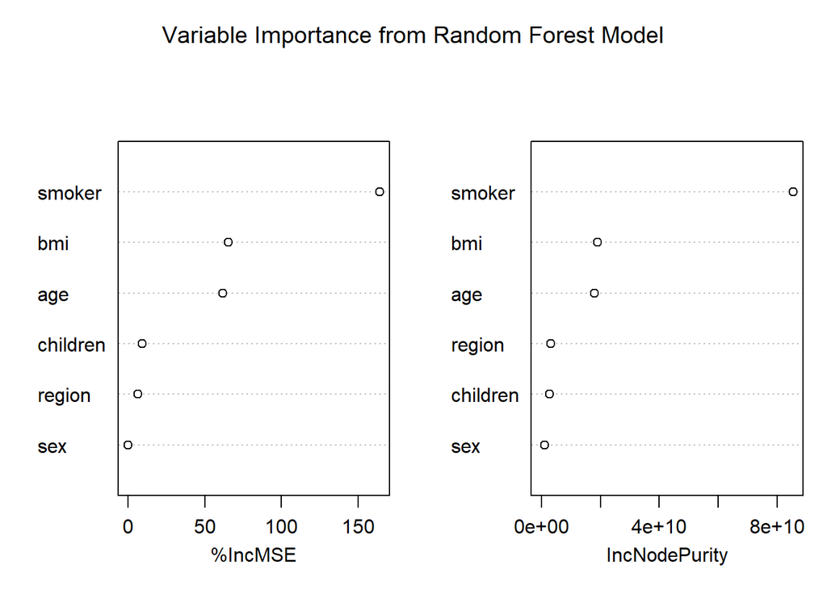

```r
varImpPlot(rf_model, main = "Variable Importance from Random Forest Model")
```

The smoker status is overwhelmingly the most important predictor. age and bmi are the next most significant drivers. region, children, and sex have minimal predictive power.

## 4.6 Residual Analysis

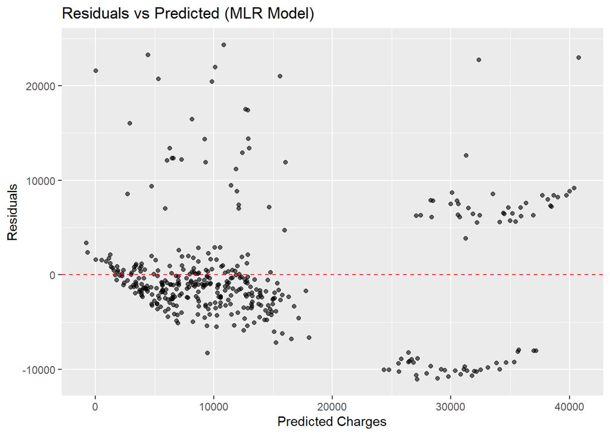

```r
residuals_mlr <- data.frame(
  Predicted = pred_mlr,
  Residuals = test_data$charges - pred_mlr
)

ggplot(residuals_mlr, aes(x = Predicted, y = Residuals)) +
  geom_point(alpha=0.6) +
  geom_hline(yintercept = 0, color = "red", linetype = "dashed") +
  labs(title = "Residuals vs Predicted (MLR Model)", x = "Predicted Charges", y = "Residuals")
```

# Modeling Summary

We used two regression models to train and predict individual medical costs (charges): Multiple Linear Regression and Random Forest Regression. Both models performed well, but Random Forest achieved a lower MSE and higher R^2 value, showing a strong predictive accuracy and the handleing of non-linear relationships.

Across both models, the most predictors that influence the model the most were smoker, bmi, and age. As we expected that a bad life style choice were associated with the large increase in predicted medical charges, while also bad bmi and old age also contributed to the total costs.

Overall, the results show that lifestyle and demographic factors such as being a smoker and bad bmi play a role in determining healthcare costs.

# 5. Classification

As a final analysis, we explored the insuranceclaim variable to predict if a customer would file a claim, using Logistic Regression and Random Forest Classification.

```r
# Check class balance
table(insure$insuranceclaim)
```

```
##
##   0   1
## 555 783
```

```r
# Convert insuranceclaim to factor if not already
insure$insuranceclaim <- as.factor(insure$insuranceclaim)

# Split into train/test (same 70/30 ratio)
set.seed(123)
train_index <- createDataPartition(insure$insuranceclaim, p = 0.7, list = FALSE)
train_class <- insure[train_index, ]
test_class  <- insure[-train_index, ]
```

## 5.1 Logistic Regression

```r
# Logistic Regression Model
log_model <- glm(insuranceclaim ~ age + sex + bmi + children + smoker + region,
                 data = train_class, family = "binomial")

# Model Summary
summary(log_model)
```

```
##
## Call:
## glm(formula = insuranceclaim ~ age + sex + bmi + children + smoker +
##     region, family = "binomial", data = train_class)
##
## Coefficients:
##              Estimate Std. Error z value Pr(>|z|)
## (Intercept) -7.004212   0.699918 -10.007  < 2e-16 ***
## age          0.030355   0.007246   4.189  2.8e-05 ***
## sex1        -0.115762   0.191585  -0.604   0.5457
## bmi          0.254181   0.022123  11.490  < 2e-16 ***
## children    -1.549017   0.118517 -13.070  < 2e-16 ***
## smoker1      4.153697   0.390661  10.632  < 2e-16 ***
## region1     -0.434880   0.272110  -1.598   0.1100
## region2     -0.398858   0.282818  -1.410   0.1585
## region3     -0.460510   0.279019  -1.650   0.0988 .
## ---
## Signif. codes:  0 '***' 0.001 '**' 0.01 '*' 0.05 '.' 0.1 ' ' 1
##
## (Dispersion parameter for binomial family taken to be 1)
##
##     Null deviance: 1272.92  on 937  degrees of freedom
## Residual deviance:  684.92  on 929  degrees of freedom
## AIC: 702.92
##
## Number of Fisher Scoring iterations: 6
```

```r
# Predictions (probabilities)
pred_log_prob <- predict(log_model, newdata = test_class, type = "response")

# Convert to binary (threshold = 0.5)
pred_log <- ifelse(pred_log_prob > 0.5, 1, 0)
pred_log <- as.factor(pred_log)

# Confusion Matrix
confusion_log <- confusionMatrix(pred_log, test_class$insuranceclaim)
print(confusion_log)
```

```
## Confusion Matrix and Statistics
##
##           Reference
## Prediction   0   1
##          0 139  24
##          1  27 210
##
##                Accuracy : 0.8725
##                  95% CI : (0.8358, 0.9036)
##     No Information Rate : 0.585
##     P-Value [Acc > NIR] : <2e-16
##
##                   Kappa : 0.7367
##
##  Mcnemar's Test P-Value : 0.7794
##
##             Sensitivity : 0.8373
##             Specificity : 0.8974
##          Pos Pred Value : 0.8528
##          Neg Pred Value : 0.8861
##              Prevalence : 0.4150
##          Detection Rate : 0.3475
##    Detection Prevalence : 0.4075
##       Balanced Accuracy : 0.8674
##
##        'Positive' Class : 0
##
```

## 5.2. Random Forest Classification

```r
set.seed(123)
rf_class <- randomForest(insuranceclaim ~ age + sex + bmi + children + smoker + region,
                         data = train_class, ntree = 500, importance = TRUE)

# Predict
pred_rf <- predict(rf_class, newdata = test_class)

# Confusion Matrix
confusion_rf <- confusionMatrix(pred_rf, test_class$insuranceclaim, positive = "1")
print(confusion_rf)
```

```
## Confusion Matrix and Statistics
##
##           Reference
## Prediction   0   1
##          0 163  12
##          1   3 222
##
##                Accuracy : 0.9625
##                  95% CI : (0.9389, 0.9789)
##     No Information Rate : 0.585
##     P-Value [Acc > NIR] : < 2e-16
##
##                   Kappa : 0.9234
##
##  Mcnemar's Test P-Value : 0.03887
##
##             Sensitivity : 0.9487
##             Specificity : 0.9819
##          Pos Pred Value : 0.9867
##          Neg Pred Value : 0.9314
##              Prevalence : 0.5850
##          Detection Rate : 0.5550
##    Detection Prevalence : 0.5625
##       Balanced Accuracy : 0.9653
##
##        'Positive' Class : 1
##
```

## 5.3 Confusion Matrix Plots

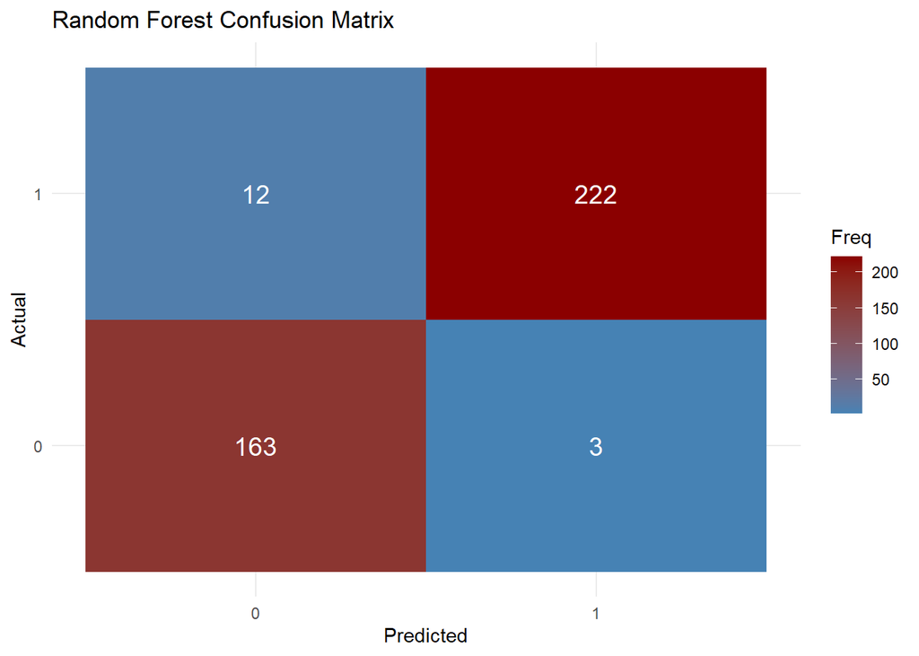

```r
cm_rf <- confusionMatrix(pred_rf, test_class$insuranceclaim)
cm_df <- as.data.frame(cm_rf$table)

ggplot(cm_df, aes(Prediction, Reference, fill = Freq)) +
  geom_tile() + geom_text(aes(label = Freq), color = "white", size = 5) +
  scale_fill_gradient(low = "steelblue", high = "darkred") +
  labs(title = "Random Forest Confusion Matrix", x = "Predicted", y = "Actual") +
  theme_minimal()
```

## 5.4 Classification Model Comparison

```r
# ROC for Logistic Regression
roc_log <- roc(test_class$insuranceclaim, pred_log_prob)
auc_log <- auc(roc_log)

# ROC for Random Forest
# We need probabilities from RF
pred_rf_prob <- predict(rf_class, newdata = test_class, type = "prob")[,2]
roc_rf <- roc(test_class$insuranceclaim, pred_rf_prob)
```

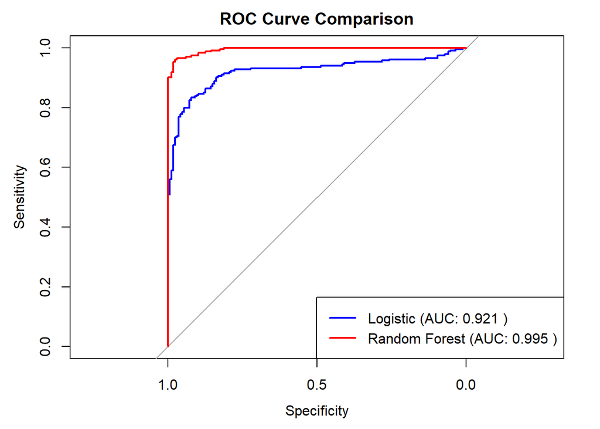

```r
auc_rf <- auc(roc_rf)

# Plot ROC Curves
plot(roc_log, col = "blue", main = "ROC Curve Comparison")
plot(roc_rf, col = "red", add = TRUE)
legend("bottomright", legend = c(paste("Logistic (AUC:", round(auc_log, 3), ")"),
                                paste("Random Forest (AUC:", round(auc_rf, 3), ")")),
       col = c("blue", "red"), lwd = 2)
```

## 6. Project Summary

- confirmed that smoker status is the primary driver of insurance costs, followed by age and bmi.
- The varImpPlot from the Random Forest model provided a clear, quantitative ranking of feature importance